# Praktikum 5 Anreg

# Library

```r
library(readxl)
library(dplyr)
library(GGally)
```

```r
library(corrplot)
library(car)
library(MASS)
```

# Data

```r
# Import data
data <- read_excel(
"C:/Users/USER/OneDrive/ドキュメント/Mata Kuliah Semester 4/Analisis Regresi/Data Pengangguran_Qurrota A'yunina_M0401241049.xlsx",
sheet="Data"
)

# Hapus peubah Provinsi
dt <- dplyr::select(data, -Provinsi)

head(dt)
```

```
## # A tibble: 6 × 7
##       Y    X1    X2       X3    X4       X5      X6
##   <dbl> <dbl> <dbl>    <dbl> <dbl>    <dbl>   <dbl>
## 1  5.64 10.4  14.2  1299756.  36.2 3685616  4155944
## 2  1.49 10.1   4    1964618.  74.3 2996561  3547519
## 3  6.69  9.82  5.84 1750546.  73.7 3876600  9539824
## 4  3.41  9.71 13.6  1498744.  33.5 2905120. 1608738
## 5  3.46 10.6  10.8  1843212.  78   2670039. 3049126
## 6  6.05 11.6   4.3  2962412. 100   2264081. 8430623
```

```r
str(dt)
```

```
## tibble [38 × 7] (S3: tbl_df/tbl/data.frame)
##  $ Y : num [1:38] 5.64 1.49 6.69 3.41 3.46 6.05 3.42 4.26 6.77 4.66 ...
##  $ X1: num [1:38] 10.42 10.07 9.82 9.71 10.58 ...
##  $ X2: num [1:38] 14.23 4 5.84 13.56 10.83 ...
##  $ X3: num [1:38] 1299756 1964618 1750546 1498744 1843212 ...
##  $ X4: num [1:38] 36.2 74.3 73.7 33.5 78 100 48.9 34.8 83.1 54.3 ...
##  $ X5: num [1:38] 3685616 2996561 3876600 2905120 2670039 ...
##  $ X6: num [1:38] 4155944 3547519 9539824 1608738 3049126 ...
```

```r
summary(dt)
```

```
##        Y               X1               X2              X3
##  Min.   :1.490   Min.   : 4.760   Min.   : 4.00   Min.   :1028875
##  1st Qu.:3.500   1st Qu.: 8.932   1st Qu.: 6.32   1st Qu.:1368587
##  Median :4.210   Median : 9.575   Median :10.13   Median :1495638
##  Mean   :4.468   Mean   : 9.457   Mean   :11.15   Mean   :1589662
##  3rd Qu.:5.545   3rd Qu.:10.092   3rd Qu.:14.06   3rd Qu.:1744522
##  Max.   :6.960   Max.   :11.580   Max.   :32.97   Max.   :2962412
##        X4               X5                X6
##  Min.   : 23.00   Min.   :2169349   Min.   :  336718
##  1st Qu.: 37.90   1st Qu.:2907590   1st Qu.: 1171362
##  Median : 52.80   Median :3321268   Median : 2939063
##  Mean   : 53.99   Mean   :3315762   Mean   : 5741258
##  3rd Qu.: 73.19   3rd Qu.:3649059   3rd Qu.: 4896332
##  Max.   :100.00   Max.   :5396761   Max.   :39237385
```

Data yang digunakan adalah data tingkat provinsi di Indonesia tahun 2025 yang terdiri atas 38 provinsi dengan 1 peubah respon dan 6 peubah penjelas.

1. Y = Tingkat Pengangguran Terbuka (Persen)
2. X1 = Rata-rata Lama Sekolah
3. X2 = Jumlah Penduduk Miskin (Ribu)
4. X3 = Pengeluaran Per Kapita (Rupiah)
5. X4 = Penduduk Daerah Perkotaan (Persen)
6. X5 = Upah Minimum Provinsi (Rupiah)
7. X6 = Jumlah Penduduk Usia Produktif (Orang)

# Eksplorasi Data

```r
options(digits=7)
options(scipen=999)
```

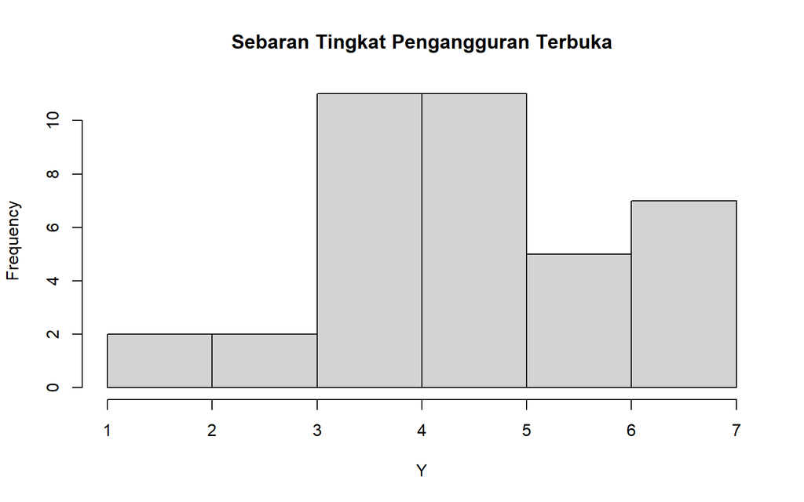

```r
hist(
dt$Y,
main="Sebaran Tingkat Pengangguran Terbuka",
xlab="Y"
)
```

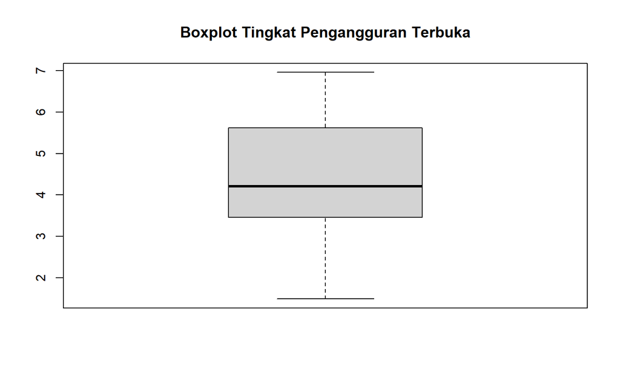

```r
boxplot(
dt$Y,
main="Boxplot Tingkat Pengangguran Terbuka"
)
```

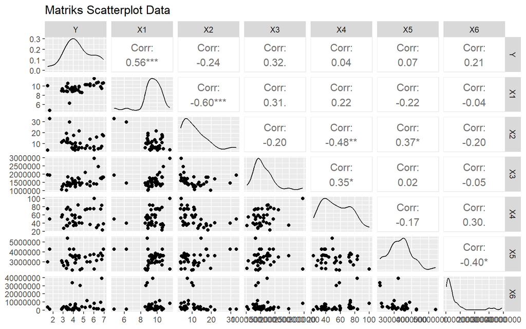

```r
ggpairs(
dt,
upper=list(
continuous=
wrap(
"cor",
digits=2,
size=4
)
),
title="Matriks Scatterplot Data"
)
```

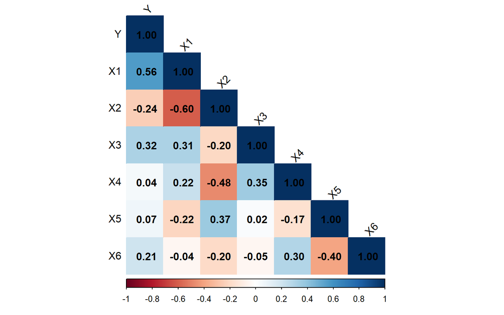

```r
cor_matrix <- cor(dt)

corrplot(
cor_matrix,
method="color",
type="lower",
addCoef.col="black",
number.digits=2,
tl.col="black",
tl.srt=45
)
```

Selain itu, terdapat korelasi tinggi antar peubah penjelas, baik lebih dari 0.5 maupun kurang dari -0.5 yaitu X1 dan X2 memiliki korelasi -0.60.

Korelasi yang tinggi ini mengindikasikan adanya potensi multikolinearitas, yang dapat memengaruhi keakuratan model yang akan dibentuk.

# Pemodelan

## Tanpa Fungsi

```r
n <- nrow(dt)

x0 <- rep(1,n)

x <- data.frame(
x0,
dt$X1,
dt$X2,
dt$X3,
dt$X4,
dt$X5,
dt$X6
)

x <- as.matrix(x)

y <- dt$Y

beta_duga <- qr.solve(
x,
y
)

beta_duga
```

```
##                x0             dt.X1             dt.X2             dt.X3
## -6.24330465430127  0.79713339194691  0.01442154951668  0.00000079952929
##             dt.X4             dt.X5             dt.X6
## -0.01693897785269  0.00000067702375  0.00000007153283
```

Selang kepercayaan dan pengujian signifikansi setiap parameter dapat dilakukan dengan menghitung keragaman tiap dugaan parameter. Secara umum, nilai ragam dugaan parameter $\hat{\beta}_j$ dapat dihitung melalui rumus berikut.

$$Var(\hat{\beta}_j) = \hat{\sigma}^2
C_{jj}$$

Persamaan:

```r
model <- lm(
Y ~ X1 + X2 + X3 + X4 + X5 + X6,
data=dt
)

coef(model)
```

```
##       (Intercept)                X1                X2                X3
## -6.24330465430127  0.79713339194691  0.01442154951668  0.00000079952929
##                X4                X5                X6
## -0.01693897785269  0.00000067702375  0.00000007153283
```

Unsur diagonal dari matriks $C$ dapat digunakan untuk menghitung nilai galat baku dari setiap dugaan parameter. Galat baku ini dapat digunakan untuk menghitung selang kepercayaan dari dugaan yang dihasilkan.

$$SE(\hat{\beta}_j) =
\sqrt{Var(\hat{\beta}_j)} = \sqrt{\sigma^2 C_{jj}} =
\hat{\sigma}\sqrt{c_{ii}}$$

```r
summary(model)
```

```
##
## Call:
## lm(formula = Y ~ X1 + X2 + X3 + X4 + X5 + X6, data = dt)
##
## Residuals:
##      Min       1Q   Median       3Q      Max
## -2.94623 -0.56122  0.07102  0.50524  1.79175
##
## Coefficients:
##                   Estimate     Std. Error t value Pr(>|t|)
## (Intercept) -6.24330465430  2.31998716072  -2.691 0.011373 *
## X1           0.79713339195  0.18672332298   4.269 0.000172 ***
## X2           0.01442154952  0.03610261956   0.399 0.692293
## X3           0.00000079953  0.00000051344   1.557 0.129578
## X4          -0.01693897785  0.01090271128  -1.554 0.130419
## X5           0.00000067702  0.00000028430   2.381 0.023573 *
## X6           0.00000007153  0.00000002166   3.302 0.002422 **
## ---
## Signif. codes:  0 '***' 0.001 '**' 0.01 '*' 0.05 '.' 0.1 ' ' 1
##
## Residual standard error: 1.016 on 31 degrees of freedom
## Multiple R-squared:  0.5469, Adjusted R-squared:  0.4592
## F-statistic: 6.236 on 6 and 31 DF,  p-value: 0.0002237
```

## VIF

```r
vif(model)
```

```
##       X1       X2       X3       X4       X5       X6
## 1.770442 2.127371 1.269797 1.571744 1.354049 1.345414
```

## Selang Kepercayaan Beta

```r
beta_duga <- coef(model)

sigma2 <- summary(model)$sigma^2

C <- ginv(t(x)%*%x)

diag_C <- diag(C)

se_beta <- sqrt(
sigma2*diag_C
)

se_beta
```

```
## [1] 0.00000000000005723971 0.00000000000098940280 0.00000000000160722406
## [4] 0.00000036212972785515 0.00000000000860330289 0.00000016824664801251
## [7] 0.00000001852582625915
```

Misal untuk β2:

```r
alfa <- 0.05

n <- nrow(dt)

p <- length(beta_duga)

bb.b2 <-
beta_duga[3] -
abs(
qt(
alfa/2,
df=n-p
)
)*se_beta[3]

ba.b2 <-
beta_duga[3] +
abs(
qt(
alfa/2,
df=n-p
)
)*se_beta[3]

bb.b2
```

```
##         X2
## 0.01442155
```

```r
ba.b2
```

```
##         X2
## 0.01442155
```

Dengan demikian, kita dapat ketahui selang kepercayaan untuk $\hat{\beta}_2$ sebagai berikut.
$$0.014421549513399150103
<\hat{\beta}_2<0.014421549519955058696$$

## Model Akhir (Peubah Signifikan)

```r
model_signif <- lm(
Y ~ X1 + X5 + X6,
data=dt
)

summary(model_signif)
```

```
##
## Call:
## lm(formula = Y ~ X1 + X5 + X6, data = dt)
##
## Residuals:
##     Min      1Q  Median      3Q     Max
## -3.0837 -0.6840  0.1079  0.5271  1.8847
##
## Coefficients:
##                   Estimate     Std. Error t value Pr(>|t|)
## (Intercept) -5.58049364983  1.93298690249  -2.887  0.00672 **
## X1           0.76770323465  0.14909491213   5.149 0.000011 ***
## X5           0.00000073922  0.00000028270   2.615  0.01321 *
## X6           0.00000005872  0.00000002110   2.783  0.00874 **
## ---
## Signif. codes:  0 '***' 0.001 '**' 0.01 '*' 0.05 '.' 0.1 ' ' 1
##
## Residual standard error: 1.042 on 34 degrees of freedom
## Multiple R-squared:  0.4773, Adjusted R-squared:  0.4312
## F-statistic: 10.35 on 3 and 34 DF,  p-value: 0.00005484
```

## Perbandingan Model

```r
perbandingan <- data.frame(
Model=
c(
"Penuh",
"Signifikan"
),

Adjusted_R2=
c(
summary(model)$adj.r.squared,
summary(model_signif)$adj.r.squared
),

AIC=
c(
AIC(model),
AIC(model_signif)
),

BIC=
c(
BIC(model),
BIC(model_signif)
)
)

perbandingan
```

```
##        Model Adjusted_R2      AIC      BIC
## 1      Penuh   0.4592091 117.2922 130.3929
## 2 Signifikan   0.4312044 116.7210 124.9089
```

Berdasarkan indikator Adjusted R-square, AIC, dan BIC, dipilih model dengan peubah signifikan sebagai model terbaik. Meskipun model penuh memiliki nilai Adjusted R-square yang sedikit lebih tinggi, model peubah signifikan menghasilkan nilai AIC dan BIC yang lebih kecil sehingga memberikan keseimbangan yang lebih baik antara kemampuan prediksi dan kesederhanaan model. Oleh karena itu, model akhir menggunakan peubah X1, X5, dan X6. Persamaan yang terbentuk adalah sebagai berikut

$$\hat{PPM}=−5.5805+0.7677X1+0.0000007392X5+0.0000000587X6$$

Interpretasi: 1. Dugaan rata-rata Tingkat Pengangguran Terbuka ketika X1, X5, dan X6 bernilai 0 adalah sebesar −5,5805%. 2. Dugaan rata-rata Tingkat Pengangguran Terbuka akan meningkat sebesar 0,7677% apabila X1 meningkat satu satuan, dengan asumsi peubah X5 dan X6 konstan. 3. Dugaan rata-rata Tingkat Pengangguran Terbuka akan meningkat sebesar 0,0000007392% apabila X5 meningkat satu satuan, dengan asumsi peubah X1 dan X6 konstan. 4. Dugaan rata-rata Tingkat Pengangguran Terbuka akan meningkat sebesar 0,0000000587% apabila X6 meningkat satu satuan, dengan asumsi peubah X1 dan X5 konstan.